# Reproducible Research Project 1

Joakim Kalvenes

December 12, 2017

## Analysis of Activity Logs Produced by Personal Activity Monitoring Devices

Personal, portable devices, such as smart watches and fitness trackers, can collect large volumes of activity data. In this study, we will analyze a set of step counts and highlight how step count for an individual varies by time of day as well as day of week (specifically, between weekdays and weekends).

The data set used in this study was collected by a single, anonymous individual from 01 October to 30 November of 2012. It was downloaded from the [course website](https://d396qusza40orc.cloudfront.net/repdata%2Fdata%2Factivity.zip) and then unzipped in a local directory.

### Reading and Unzipping the Data

We assume that the data file, activity.zip, is in the local directory.

```r
library(readr)
library(dplyr)
library(data.table)
# Unzip and read data from file in local directory
activityData <- read.csv(unz("activity.zip", "activity.csv"), header=TRUE,
                 na.strings = "NA")
# Convert date format
activityData$date <- as.Date(activityData$date, format = "%Y-%m-%d")
```

### Data Dictionary

The data set consists of three attributes:

1. steps: The number of steps (by time period)
2. date: The date of data collection
3. interval: The time index for data collection (beginning of time period in increments of 5 minutes from midnight)

### Analyzing Step Count on Raw Data

In this section, we analyze the activity data (step count) without regard to missing data. This will generate some bias that we will examine in a later section. Specifically, the summary counts by time period will be zero if data are missing, thereby reducing the daily step count. Consequently, the mean values are likely lower than if we had a complete data set.

First, we find the number of steps taken per day by summing over all time periods (intervals) each day:

```r
# Find the total number of steps taken in a day
stepsByDay <- activityData %>% group_by(date) %>%
      summarise(totalSteps=sum(steps, na.rm = TRUE))
stepsByDay <- data.table(stepsByDay)
```

The result of this compilation is shown in the histogram below:

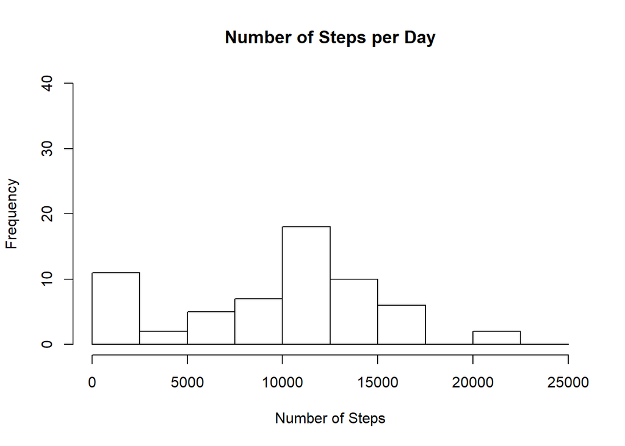

```r
# Histogram of the number of steps per day
hist(stepsByDay$totalSteps, main = "Number of Steps per Day", xlab = "Number of Steps", ylab = "Frequency",
     breaks = c(0,2500,5000,7500,10000,12500,15000,17500,20000,22500,25000), ylim = c(0,40))
```

The relatively large frequency in the smallest bin (0-2,500 steps per day) is due to missing values in the data set. The median and mean number of steps per day are given by the following formulae

```r
# Median and mean number of steps per day (single numbers)
medSteps <- median(stepsByDay$totalSteps)
meanSteps <- round(mean(stepsByDay$totalSteps),2)
```

which produced a median of 10395 and a mean of 9354.23.

Next, we are interested in how activity is related to time of day. We calculate the average number of steps per period (interval), keeping in mind that each interval represents a 5-minute period starting at midnight in the format hhmm. For example, the interval labeled 600 is the time slot 6:00-6:05 a.m.

```r
# Find the number of steps per time period across dates
stepsByPeriod <- activityData %>% group_by(interval) %>%
      summarise(avgSteps=mean(steps, na.rm = TRUE))
stepsByPeriod <- data.table(stepsByPeriod)
```

The average activity pattern is displayed in the following graph:

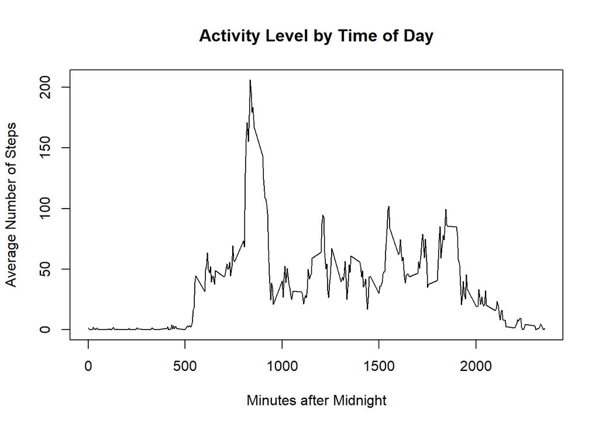

```r
plot(stepsByPeriod, type = "l", xlab = "Minutes after Midnight", ylab = "Average Number of Steps",
     main = "Activity Level by Time of Day")
```

We find the maximum average number of steps by time period with the following procedure:

```r
# Find the time period with the largest average number of steps
# Of course, you cannot apply which.max to a data frame, so first,
# stepsByPeriod has to be converted to a matrix...
stepsByPeriodMatrix <- as.matrix(stepsByPeriod)
maxStepPeriod <- stepsByPeriodMatrix[which.max(stepsByPeriodMatrix[,2]),1]
```

which shows that the activity level, on average, is highest during time period 835.

### Imputing Missing Values

As mentioned previously, missing values are likely to bias the results in a negative direction (i.e., underestimating the number of steps taken per day or per time period). There are several ways in which the missing values could be imputed. In this analysis, we are going to use the average number of minutes per time period to replace the missing steps data. To gauge the severity of the missing data problem, we identify the number of missing values.

```r
# First, find out how many rows have missing values
missingRowValues <- sum(!complete.cases(activityData))
missingStepsByDay <- activityData %>% group_by(date) %>%
      summarise(totalSteps=sum(steps))
missingDateValues <- sum(!complete.cases(missingStepsByDay))
```

There are 2304 time periods with missing data, distributed across 8 days. Next, we insert the imputed values into the data set:

```r
# Use average number of steps per time period from stepsByPeriod to impute
# the missing values by time period (regardless of day of week)
naIdx <- which(is.na(activityData$steps))
crIdx <- match(activityData$interval,stepsByPeriod$interval)
actDataImputed <- activityData
actDataImputed$steps <- as.numeric(actDataImputed$steps)
actDataImputed[naIdx,1] <- stepsByPeriod[crIdx[naIdx],2]
```

From the new data frame, we can compute the revised average number of steps per day,

```r
# Find the total number of steps taken in a day
stepsByDayImputed <- actDataImputed %>% group_by(date) %>%
      summarise(totalSteps=sum(steps, na.rm = TRUE))
stepsByDayImputed <- data.table(stepsByDayImputed)
```

which is displayed in a histogram below.

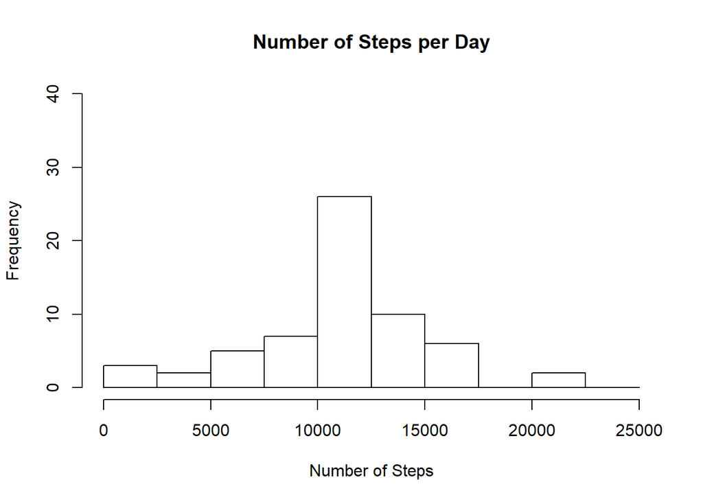

```r
# Histogram of the number of steps per day
hist(stepsByDayImputed$totalSteps, main = "Number of Steps per Day", xlab = "Number of Steps",
     ylab = "Frequency", ylim = c(0,40), xlim = c(0,25000),
     breaks = c(0,2500,5000,7500,10000,12500,15000,17500,20000,22500,25000))
```

As predicted, the number of days with 0-2500 steps taken is reduced noticeably from the analysis in which we did not impute missing values. The median and mean number of steps per day were also re-computed according to:

```r
# Median and mean number of steps per day (single numbers)
medImp <- as.numeric(median(stepsByDayImputed$totalSteps))
meanImp <- mean(stepsByDayImputed$totalSteps)
```

The revised median is 10766.19 steps per day, while the mean is 10766.19 steps per day. Incidentally, the median and mean values are the same as there are several days with the mean value of steps due to the 8 days with imputed values.

### Activity by Day of the Week

We hypothesize that activity levels might differ between days of the week. In particular, we are interested in the difference between weekday and weekend activity levels. First, we need to split the data set by weekdays and weekend days. Then, we calculate the average number of steps per day for the two classes.

```r
# Define weedayDays and weekendDays
weekdayDays <- c("Monday","Tuesday","Wednesday","Thursday","Friday")
weekendDays <- c("Saturday","Sunday")

# Classify data rows by weekday v. weekend
idxWk <- which(weekdays(actDataImputed$date) %in% weekdayDays)
idxWe <- which(weekdays(actDataImputed$date) %in% weekendDays)
actDataImputed$dayOfWk <- NA
actDataImputed$dayOfWk[idxWk] <- "weekday"
actDataImputed$dayOfWk[idxWe] <- "weekend"

stepsOnWeekdays <- actDataImputed[actDataImputed$dayOfWk == "weekday",]
stepsOnWeekends <- actDataImputed[actDataImputed$dayOfWk == "weekend",]

stepsByPeriodOnWD <- stepsOnWeekdays %>% group_by(interval) %>%
      summarise(avgSteps=mean(steps, na.rm = TRUE))
stepsByPeriodOnWD <- data.table(stepsByPeriodOnWD)

stepsByPeriodOnWE <- stepsOnWeekends %>% group_by(interval) %>%
      summarise(avgSteps=mean(steps, na.rm = TRUE))
stepsByPeriodOnWE <- data.table(stepsByPeriodOnWE)
```

The difference in activity level by weekdays v. weekends is evident in the figure below.

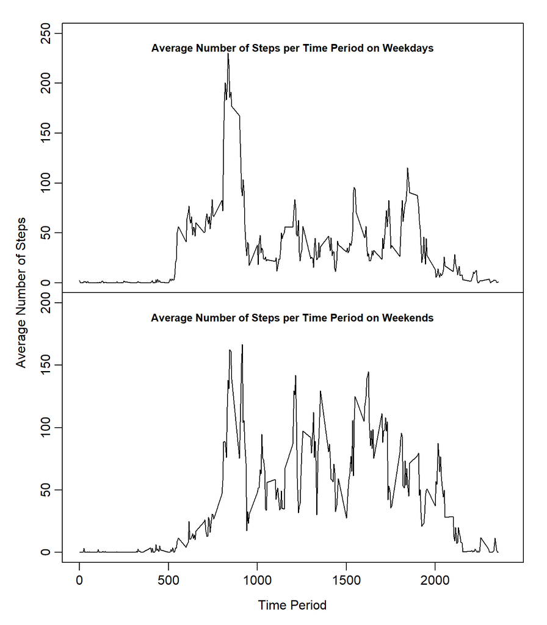

```r
par(mfrow = c(2, 1))
par(mar=c(0,0,0,0))
par(oma=c(4,4,1.5,1.5))
par(cex.main = 0.8)
par(mgp = c(2,0.6,0))
plot(stepsByPeriodOnWD, type = "l", xlim = c(0,2400), ylim = c(0,250), xaxt = "n")
title("Average Number of Steps per Time Period on Weekdays", line = -1.8)
plot(stepsByPeriodOnWE, type = "l", xlim = c(0,2400), ylim = c(0,200))
title("Average Number of Steps per Time Period on Weekends", line = -1.8)
mtext("Time Period", side = 1, outer = TRUE, cex = 1.0, line = 2.2)
mtext("Average Number of Steps", side = 2, outer = TRUE, cex = 1.0, line = 2.2)
```

We observe that weekday peak activity is higher than that on weekends. At the same time, the weekend activity level is higher mid-day than on weekdays.